# Breadth and Quality of Internet Access Around the World

## Introduction

Quote from an article in the MIT Technology Review by Manuel Castells:

> “The Internet is the decisive technology of the Information Age, and with the explosion of wireless communication in the early twenty-first century, we can say that humankind is now almost entirely connected, albeit with great levels of inequality in bandwidth, efficiency, and price.”
- Conduct extensive analysis using data from CIA World Factbook and the democracy index developed by the Economist Intelligence Unit.

## Objectives

We aim to investigate the following details:

1. *Define our methods* as to how internet usage is measured in a country, and base our analysis on them.
2. Examine and analyze the *difference*, as defined by our group, in *internet usage in each country*.
3. Examine and analyze the *impact of democracy, education, economy, and health*, as defined by our group, on internet usage, as defined by our group.

## What defines Internet Access?

## Data Overview

| Field | Type | Contents |
| --- | --- | --- |
| Country | str | Name of Country |
| Population | dbl | Amounts of Residents |
| Broadband | dbl | Amount of Broadband Connections |
| InternetUsers | dbl | Number of Internet Users |
| DemocracyScore | dbl | Democracy Score |
| Education | dbl | Percentage GDP on Education |
| GDP | dbl | GDP Per Capita |
| LifeExpectancy | dbl | Average Life Expectancy |

## Problem Definition

### Metric for “Internet Access”

We define the quality of the Internet access of a country based on 2 main criterion:

1. The amount/proportion of the population having Internet access \[\text{InternetUserProp}=\frac{\text{InternetUsers}}{\text{Population}}\]
2. The quality (congested ness) of Internet access (i.e. worse when one connection is shared between many people) \[\text{PersonPerBroadband}=\frac{\text{InternetUsers}}{\text{Broadband}}\]

These can be computed with the existing data.

## Initial Observations

After computing the 2 variables, we can plot them on a scatter-plot. On which, we attempt to find patterns (clusters) of the state of the country.

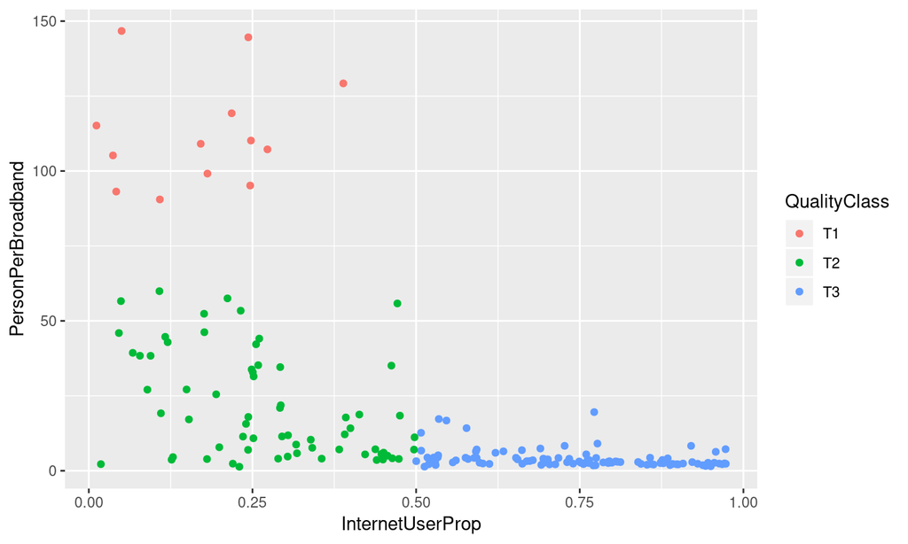

## Country Classifications

We can divide the countries into 3 segments:

1. Countries with **small internet reach** with **resources shared among more people**

   Definition: \(\text{InternetUserProp} < 0.5\) and \(\text{PersonPerBroadband} \geq 75\)
2. Countries with **small internet reach**, but **has relatively private/good access**

   Definition: \(\text{InternetUserProp} < 0.5\) and \(\text{PersonPerBroadband} < 75\)
3. Countries with **large reach** while having private/good access

   Definition: \(\text{InternetUserProp} \geq 0.5\)

## Metrics for Further Analysis

### Continuous Metrics

We use *`InternetUserProp`* and *`PersonPerBroadband`* as continuous metrics, used in linear regression.

### Discrete Metrics

With *`QualityClass`*, we can divide the countries into segments, and observe the situation more qualitatively.

## Regional Impact on Access

## Continents vs Internet Access

### Maps (InternetUserProp)

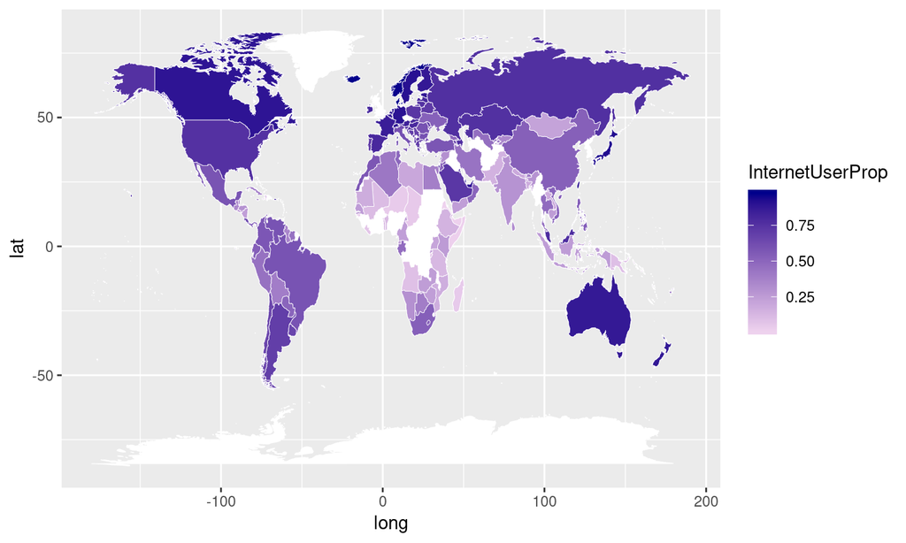

## Continents vs Internet Access

### Map (PersonPerBroadband)

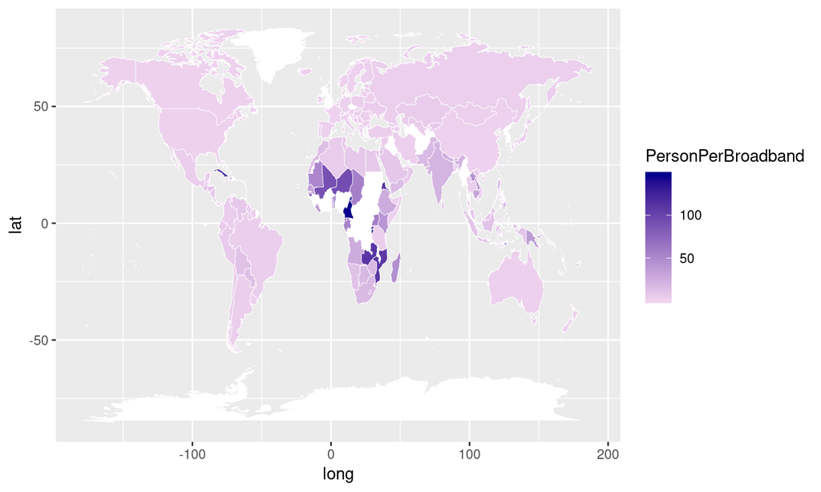

## Classification Tree

### Statistical Methods

- Split the data 80/20 into train and test set
- Build a classification tree to predict which quality class a country belongs to, and check its accuracy using train and test set
- Response Variable: QualityClass
- Predictors: continent, lat, long

## Classification Tree

\(\text{Accuracy}_\text{testing}=0.8838048\)

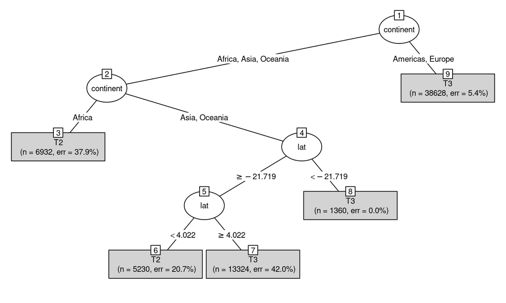

## Continents vs Internet Access

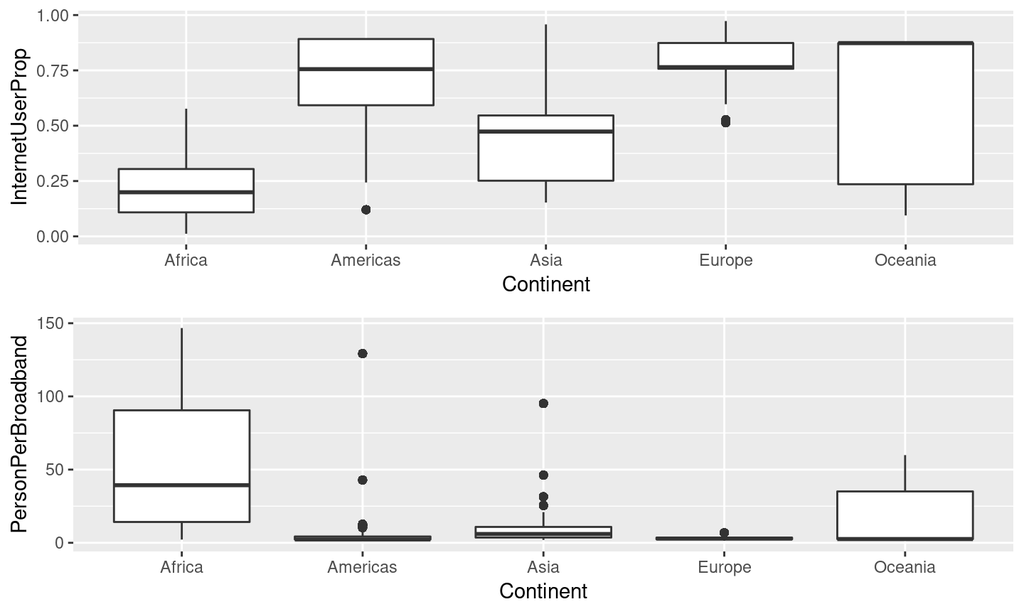

## Impacts of Other Parameters

## Impact of Democracy

### Democracy Score

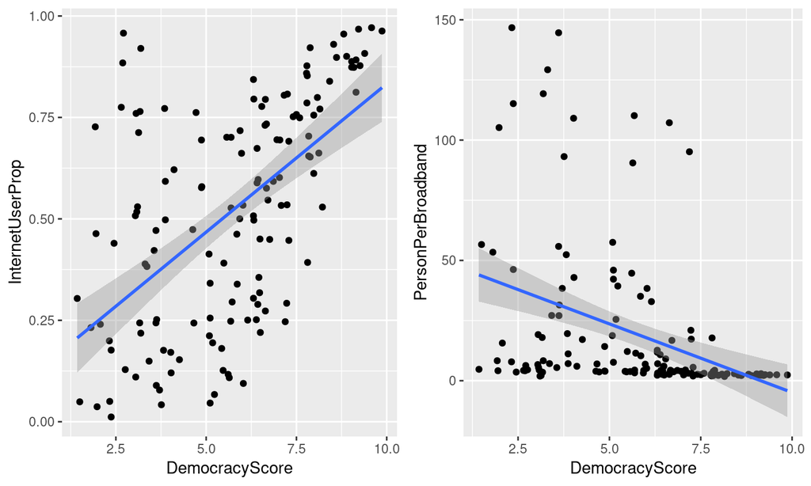

\(P=5.24\times 10^{-15},R^2=0.337575 \hspace{15pt} P=4.4\times 10^{-4}, R^2=0.07983221\)

## Impact of Education

### Percentage GDP Spent in Education

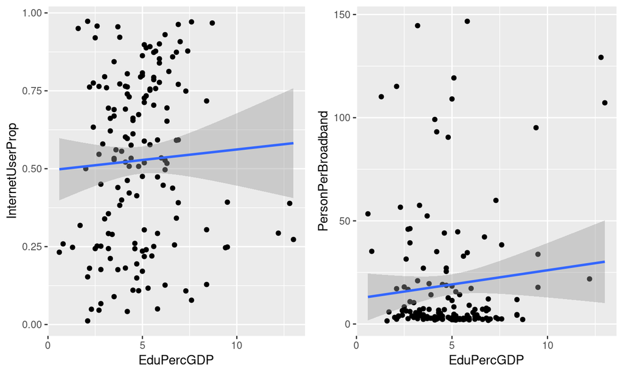

\(P=0.7073,R^2=0.0008948317 \hspace{20pt} P=0.8744, R^2=0.0001587007\)

## Impact of GDP Per Capita

### GDP Per Capita

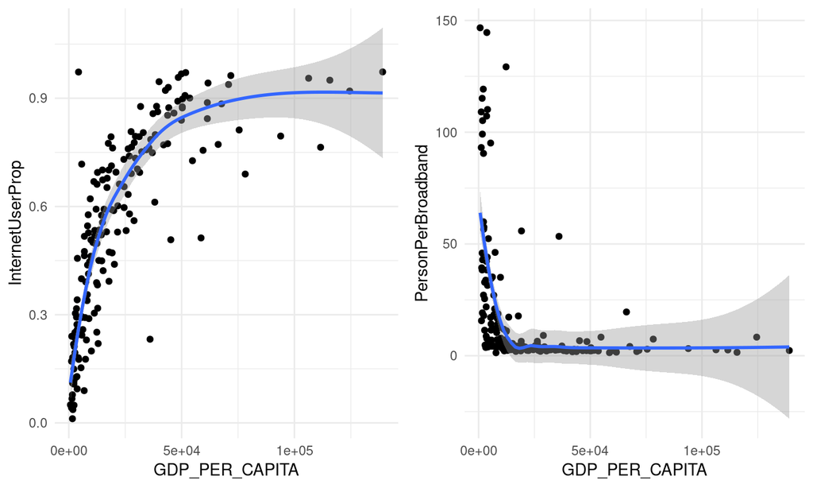

\(P=<2.0\times 10^{-16},R^2=0.7777613 \hspace{15pt} P=2.97\times 10^{-7}, R^2=0.1294\)

## Impact of Life Expetancy

### Average Life Span of Citizen

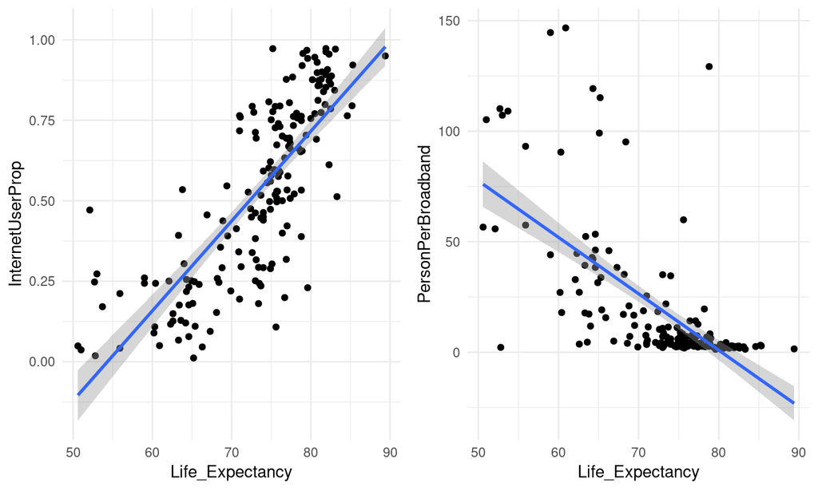

\(P=<2.0\times 10^{-16},R^2=0.59707 \hspace{15pt} P=6.45\times 10^{-10}, R^2=0.18247\)

## Conclusion

- Objective: Examine and analyze differences in internet access and quality around the world.
- Breadth and quality of Internet access varies greatly by region.
- Democracy impacts the internet use of a country but education does not.
- Positive correlation between GDP Per Capita and Life Expectancy with internet usage.

## Possible Future Investigations

1. Does Internet access propel democracy, or is it the other way around?
2. Is there a shift of educatedness of Internet users over time?
3. Do the 4 factors introduced exist as possible solutions to increase Internet access?